# A social learning simulation in R

### Different calculations of VOM, AV, and VOV

1. Interquartile range (VOM), pooled standard deviation, pooled standard deviation (AV), and coefficient of dispersion (VOV)

```r
#Here's another way to look at this but with different metrics
#For VOM we'll use the interquartile range (median 50%), for AV we'll use pooled standard deviation, and for VOV we'll use the coefficient of dispersion which is like CV in that it divides the standard deviation of SDs by the mean SD.

# Calculate pooled standard deviation for AV
pooled_sd <- function(sd, n) {
  sqrt(sum((n - 1) * sd^2) / sum(n - 1))
}

# Calculate coefficient of dispersion for VOV
coefficient_of_dispersion <- function(sd) {
  sd(sd) / mean(sd)
}

artifact_stats2 <- artifact_data %>%
  group_by(Generation, Scenario, Assemblage) %>%
  summarize(
    Mean_Length = mean(Length),
    SD_Length = sd(Length),
    n = n(), # Number of artifacts per assemblage
    .groups = 'drop'
  ) %>%
  group_by(Generation, Scenario) %>%
  summarize(
    AV = pooled_sd(SD_Length, n), # Pooled SD for AV
    VOM = IQR(Mean_Length), # IQR of Means for VOM
    VOV = coefficient_of_dispersion(SD_Length)*10 # Coefficient of Dispersion for VOV
  )
```

- Plotting the alternative measures

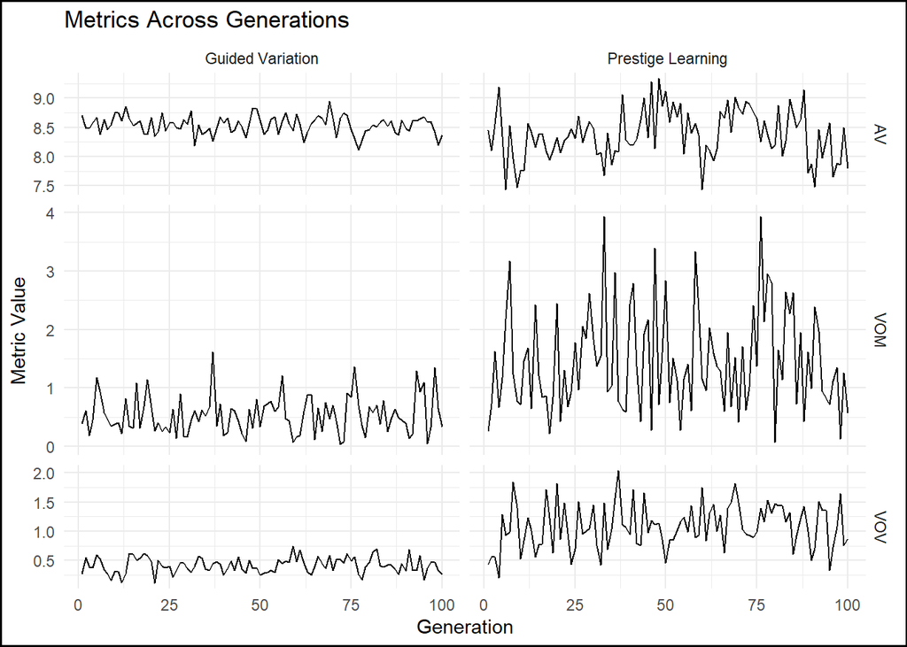

```r
# Again, we need to reshape the data to a long format
artifact_stats2_long <- artifact_stats2 %>%
  filter(Scenario!="Prestige")%>%
  gather(key = "Metric", value = "Value", VOM, AV, VOV)

# Plot the data using separate facets for each metric
ggplot(artifact_stats2_long, aes(x = Generation, y = Value)) +
  geom_line() +
  facet_grid(Metric ~ Scenario, scales = "free_y", space = "free_y") +
  labs(
    title = "Metrics Across Generations",
    x = "Generation",
    y = "Metric Value"
  ) +
  theme_minimal()+
      theme(plot.background = element_rect(color ="black", linewidth = 1))
```

2. Levenes’s Test statistic for VOV

```r
# Let's use the same method for VOM and AV but use the test statistic for Levene's test for VOV instead

artifact_stats3 <- artifact_data %>%
  group_by(Generation, Scenario, Assemblage) %>%
  summarize(
    Mean_Length = mean(Length),
    SD_Length = sd(Length),
    n = n(), # Number of artifacts per assemblage
    .groups = 'drop'
  ) %>%
  group_by(Generation, Scenario) %>%
  summarize(
    AV = pooled_sd(SD_Length, n), # Pooled SD for AV
    VOM = IQR(Mean_Length) # IQR of Means for VOM
    # VOV will be calculated separately using Levene's test
  ) %>%
  ungroup() # Make sure to ungroup for Levene's test

# Add a VOV column to the stats using Levene's test
artifact_stats3$VOV <- NA # Placeholder for VOV values

# This nested for loop calculates Levene's test for each Generation and Scenario
for(i in unique(artifact_stats3$Generation)) {
  for(j in unique(artifact_stats3$Scenario)) {
    current_data <- artifact_data %>%
      filter(Generation == i, Scenario == j) %>%
      mutate(Assemblage = as.factor(Assemblage)) # Ensure Assemblage is a factor

    if (nrow(current_data) > 1 && length(unique(current_data$Assemblage)) > 1) {
      test_result <- leveneTest(Length ~ Assemblage, data = current_data, center = median) # levene's test for length by assemblage
      f_value <- test_result$`F value`[1]  # Extract the first element of the F value column

      if (!is.na(f_value)) {
        artifact_stats3$VOV[artifact_stats3$Generation == i & artifact_stats3$Scenario == j] <- f_value
      }
    }
  }
}
```

*Plotting with Levene’s Test statistic

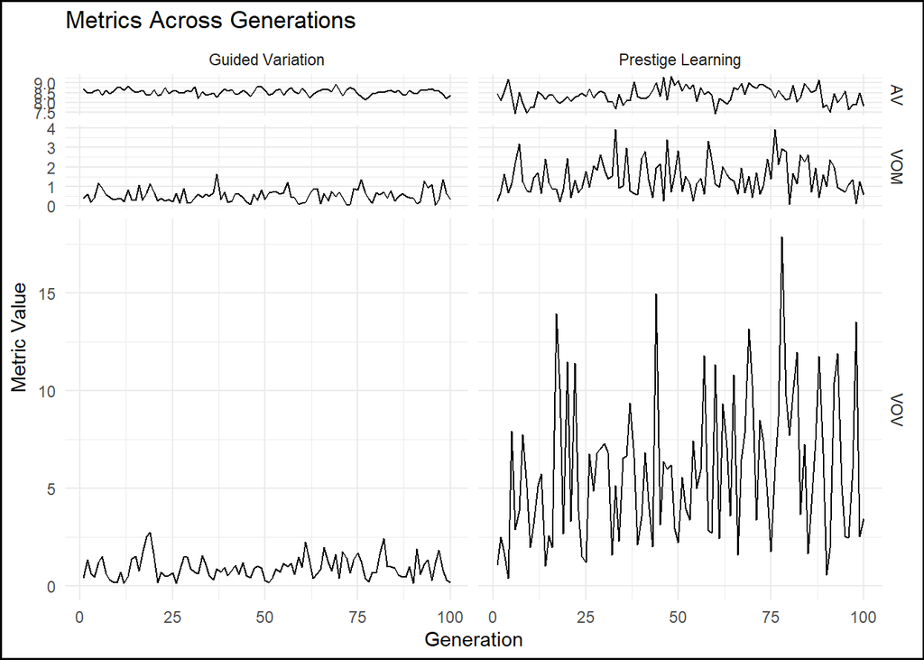

```r
# First, we need to reshape the data to a long format
artifact_stats3_long <- artifact_stats3 %>%
  filter(Scenario != "Prestige")%>%
  gather(key = "Metric", value = "Value", VOM, AV, VOV)

# Now, plot the data using separate facets for each metric
ggplot(artifact_stats3_long, aes(x = Generation, y = Value)) +
  geom_line() +
  facet_grid(Metric ~ Scenario, scales = "free_y", space = "free_y") +
  labs(
    title = "Metrics Across Generations",
    x = "Generation",
    y = "Metric Value") +
  theme_minimal()+
      theme(plot.background = element_rect(color ="black", linewidth = 1))
```

## Classifying VOM, AV, and VOV

Next, let’s consider how we might subdivide these designations using the quantile function. We can classify values as either high or low and then consider the remainders to be intermediate. This can be done over all of the generations providing a way to normalize the classifications.

```r
# Calculate global thresholds for each metric
thresholds <- artifact_stats %>%
  ungroup() %>% # Make sure we're not grouped
  summarize(
    VOM_low = quantile(VOM, probs = 0.33, na.rm = TRUE),
    VOM_high = quantile(VOM, probs = 0.67, na.rm = TRUE),
    AV_low = quantile(AV, probs = 0.33, na.rm = TRUE),
    AV_high = quantile(AV, probs = 0.67, na.rm = TRUE),
    VOV_low = quantile(VOV, probs = 0.33, na.rm = TRUE),
    VOV_high = quantile(VOV, probs = 0.67, na.rm = TRUE)
  )

# Use the thresholds to classify each metric
artifact_stats <- artifact_stats %>%
  ungroup() %>% # Make sure we're not grouped
  mutate(
    VOM_cat = case_when(
      VOM < thresholds$VOM_low ~ "Low",
      VOM > thresholds$VOM_high ~ "High",
      TRUE ~ "Intermediate"
    ),
    AV_cat = case_when(
      AV < thresholds$AV_low ~ "Low",
      AV > thresholds$AV_high ~ "High",
      TRUE ~ "Intermediate"
    ),
    VOV_cat = case_when(
      VOV < thresholds$VOV_low ~ "Low",
      VOV > thresholds$VOV_high ~ "High",
      TRUE ~ "Intermediate"
    )
  )

# Check results
print(head(artifact_stats))
```

```
## # A tibble: 6 × 8
##   Generation Scenario            VOM    AV   VOV VOM_cat      AV_cat     VOV_cat
##        <dbl> <chr>             <dbl> <dbl> <dbl> <chr>        <chr>      <chr>
## 1          1 Guided Variation  0.416  8.70 0.234 Low          High       Low
## 2          1 Prestige Learning 0.521  8.44 0.368 Low          Intermedi… Low
## 3          2 Guided Variation  0.652  8.47 0.465 Intermediate Intermedi… Interm…
## 4          2 Prestige Learning 0.616  8.09 0.457 Intermediate Low        Interm…
## 5          3 Guided Variation  1.10   8.48 0.326 Intermediate Intermedi… Low
## 6          3 Prestige Learning 1.08   8.54 0.483 Intermediate Intermedi… Interm…
```

## Expected proportions of VOM, AV, and VOV

Based on our classifications, we can determine how often we might expect to see certain classifications depending on our learning scenario. You can see below that expected VOM, AV, and VOV appear almost to be the inverse of one another.

```r
# Summarize the categorical variables for each scenario
expectations <- artifact_stats %>%
  group_by(Scenario) %>%
  summarize(
    VOM_High = mean(VOM_cat == "High"),
    VOM_Int = mean(VOM_cat == "Intermediate"),
    VOM_Low = mean(VOM_cat == "Low"),
    AV_High = mean(AV_cat == "High"),
    AV_Int = mean(AV_cat == "Intermediate"),
    AV_Low = mean(AV_cat == "Low"),
    VOV_High = mean(VOV_cat == "High"),
    VOV_Int = mean(VOV_cat == "Intermediate"),
    VOV_Low = mean(VOV_cat == "Low")
  )

# This gives us the proportion of generations in each category for each scenario
print(expectations)
```

```
## # A tibble: 2 × 10
##   Scenario       VOM_High VOM_Int VOM_Low AV_High AV_Int AV_Low VOV_High VOV_Int
##   <chr>             <dbl>   <dbl>   <dbl>   <dbl>  <dbl>  <dbl>    <dbl>   <dbl>
## 1 Guided Variat…     0       0.38    0.62    0.39   0.49   0.12     0       0.39
## 2 Prestige Lear…     0.66    0.3     0.04    0.27   0.19   0.54     0.66    0.29
## # ℹ 1 more variable: VOV_Low <dbl>
```

- Plotting the results

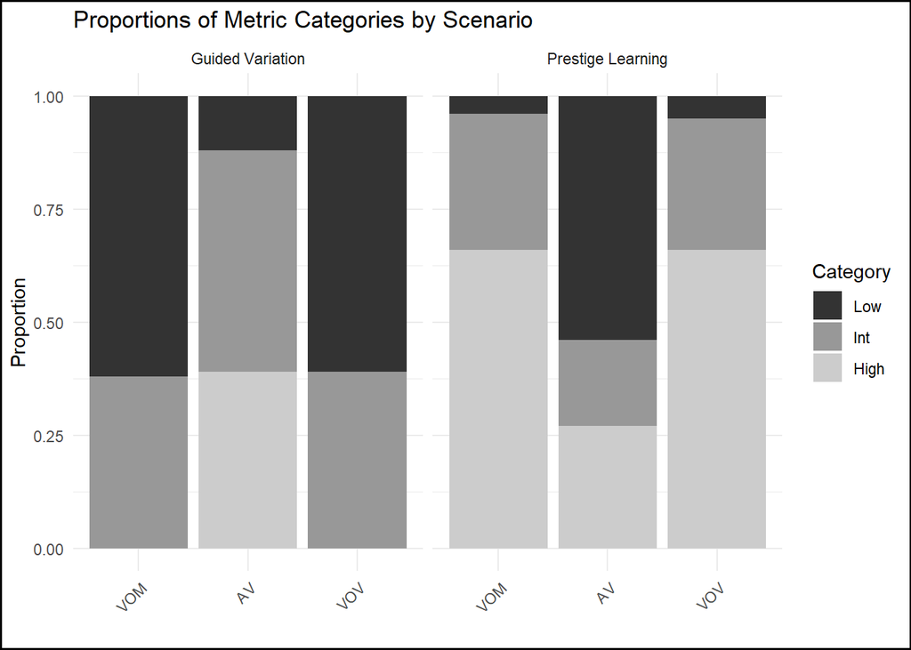

```r
# Reshape the data into long format with separate columns for metric and category
expectations_long <- expectations %>%
  pivot_longer(
    cols = starts_with("VOM_") | starts_with("AV_") | starts_with("VOV_"),
    names_to = c("Metric", "Category"),
    names_sep = "_",
    values_to = "Proportion"
  ) %>%
  mutate(
    Metric = factor(Metric, levels = c("VOM", "AV", "VOV")),
    Category = factor(Category, levels = c("Low", "Int", "High"))
  )

# Plot the data with bars for each category and facet by scenario
ggplot(expectations_long, aes(x = Metric, y = Proportion, fill = Category)) +
  geom_bar(stat = "identity", position = "stack") +
  facet_wrap(~ Scenario, scales = "free_x") +
  labs(
    title = "Proportions of Metric Categories by Scenario",
    y = "Proportion",
    x = "",
    fill = "Category"
  ) +
  scale_fill_grey() +
  theme_minimal() +
  theme(axis.text.x = element_text(angle = 45, hjust = 1),
        plot.background = element_rect(color ="black", linewidth = 1))  # Rotate x labels for readability
```

## Are VOM, AV, and VOV the same regardless of scenario?

1. Testing for normality

Since the residuals of VOM for prestige learning does not appear to be normally distributed, it probably best to explore avenues of testing and prediction other than linear regression.

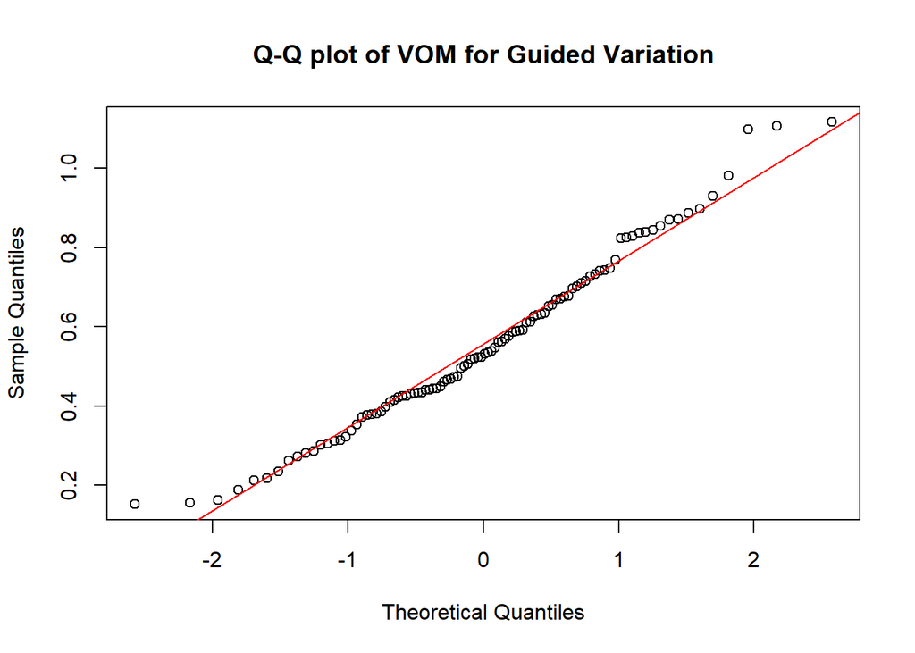

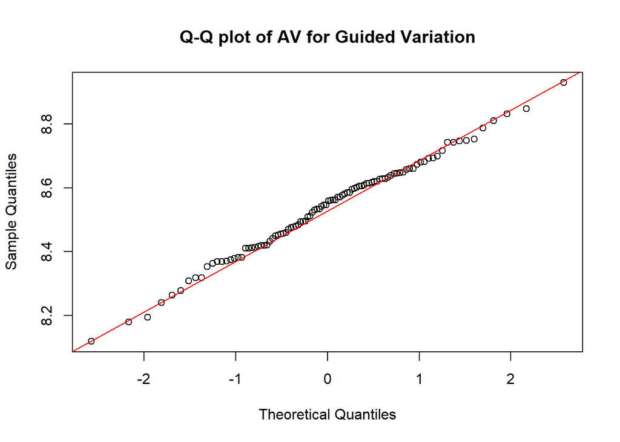

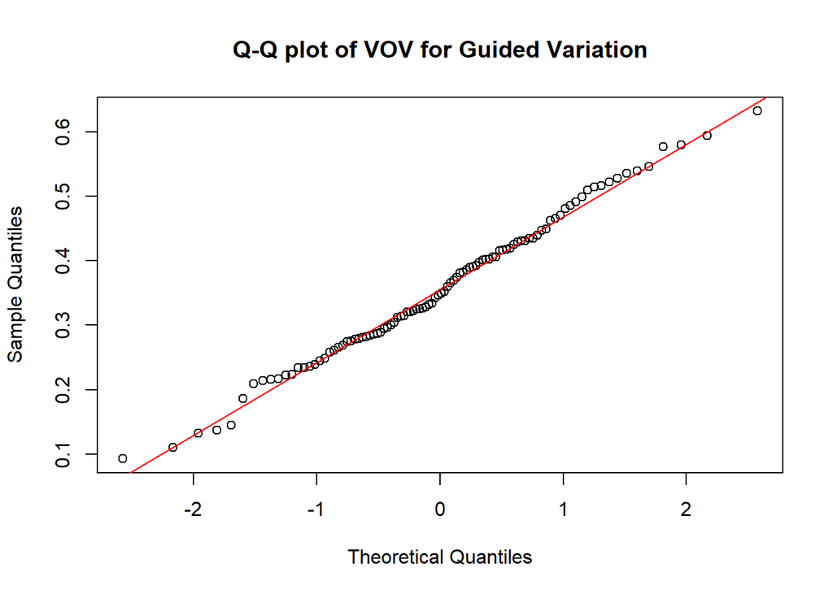

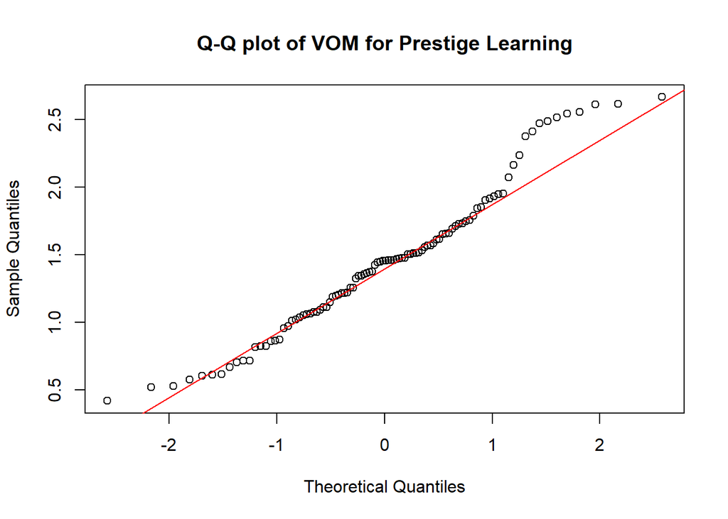

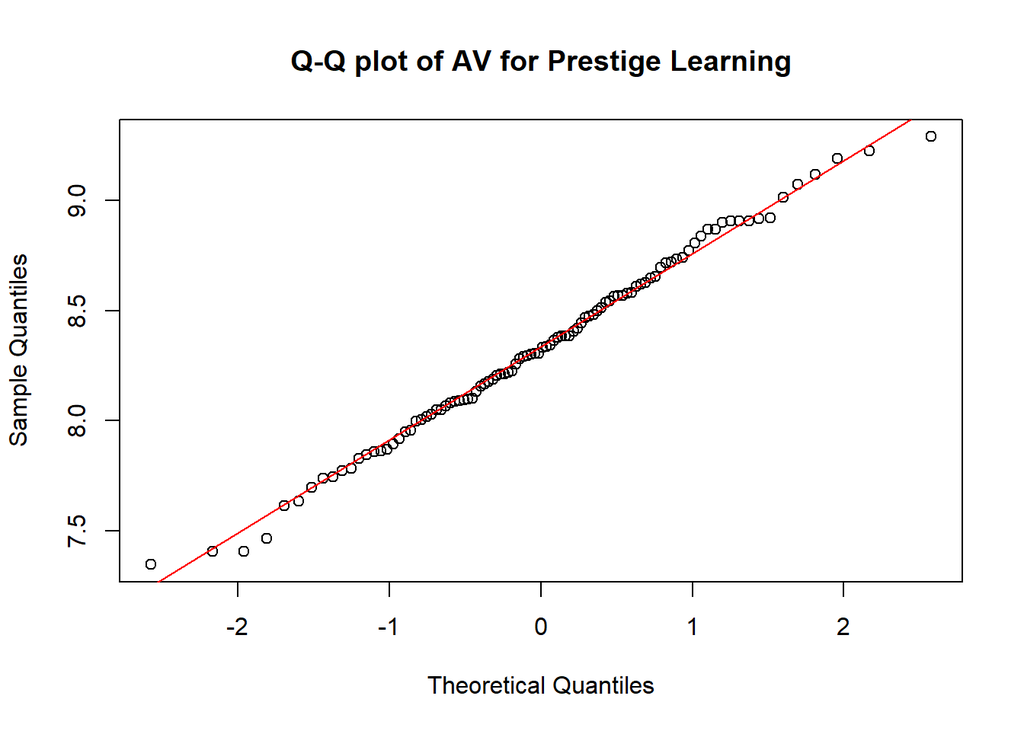

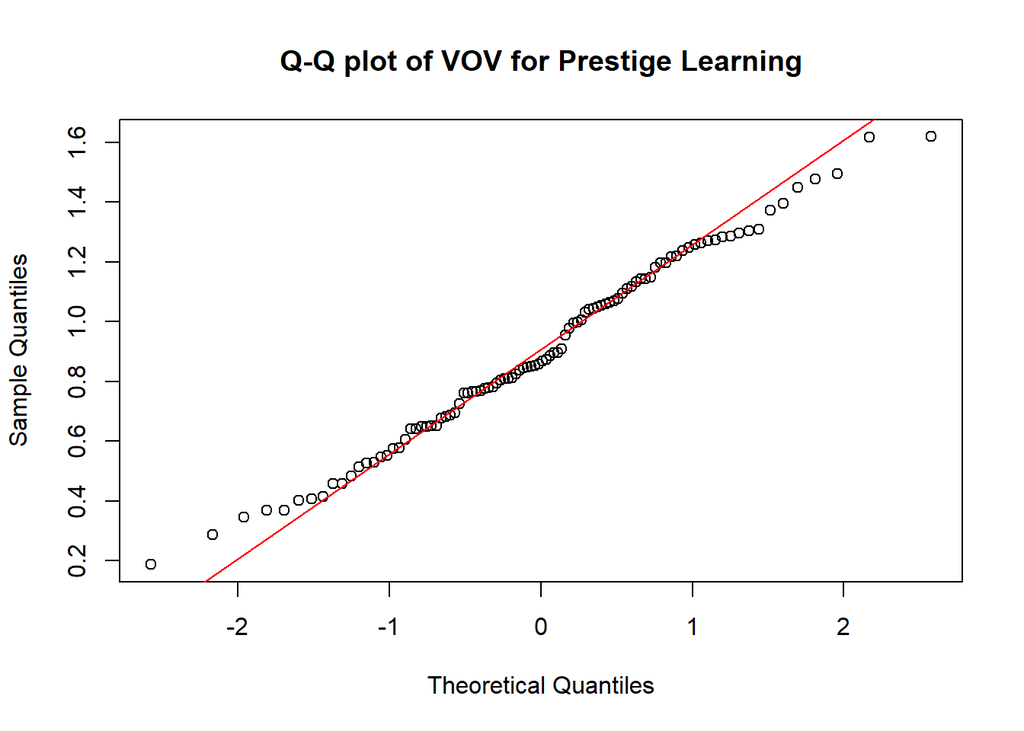

```r
# Let's check for normality

# Initialize a list to store test results
normality_tests <- list()

# Unique scenarios
scenarios <- unique(artifact_stats$Scenario)

# Perform Shapiro-Wilk normality tests for each scenario and each metric
for(scenario in scenarios) {
  # Filter data for the current scenario
  scenario_data <- artifact_stats[artifact_stats$Scenario == scenario,]

  # Shapiro-Wilk test for VOM
  shapiro_vom <- shapiro.test(scenario_data$VOM)
  # Shapiro-Wilk test for AV
  shapiro_av <- shapiro.test(scenario_data$AV)
  # Shapiro-Wilk test for VOV
  shapiro_vov <- shapiro.test(scenario_data$VOV)

  # Store the results in the list
  normality_tests[[scenario]] <- list(
    VOM = shapiro_vom,
    AV = shapiro_av,
    VOV = shapiro_vov
  )

  # Q-Q plots for each metric within the current scenario
  # VOM
  qqnorm(scenario_data$VOM, main = paste("Q-Q plot of VOM for", scenario))
  qqline(scenario_data$VOM, col = "red")
  # AV
  qqnorm(scenario_data$AV, main = paste("Q-Q plot of AV for", scenario))
  qqline(scenario_data$AV, col = "red")
  # VOV
  qqnorm(scenario_data$VOV, main = paste("Q-Q plot of VOV for", scenario))
  qqline(scenario_data$VOV, col = "red")
}
```

```r
# Check the results
normality_tests
```

```
## $`Guided Variation`
## $`Guided Variation`$VOM
##
##  Shapiro-Wilk normality test
##
## data:  scenario_data$VOM
## W = 0.97897, p-value = 0.1104
##
##
## $`Guided Variation`$AV
##
##  Shapiro-Wilk normality test
##
## data:  scenario_data$AV
## W = 0.99319, p-value = 0.899
##
##
## $`Guided Variation`$VOV
##
##  Shapiro-Wilk normality test
##
## data:  scenario_data$VOV
## W = 0.99197, p-value = 0.8191
##
##
##
## $`Prestige Learning`
## $`Prestige Learning`$VOM
##
##  Shapiro-Wilk normality test
##
## data:  scenario_data$VOM
## W = 0.96656, p-value = 0.01214
##
##
## $`Prestige Learning`$AV
##
##  Shapiro-Wilk normality test
##
## data:  scenario_data$AV
## W = 0.99269, p-value = 0.8684
##
##
## $`Prestige Learning`$VOV
##
##  Shapiro-Wilk normality test
##
## data:  scenario_data$VOV
## W = 0.98856, p-value = 0.5503
```

2. Parametric and non-parametric significance testing
- T-tests: are they significantly different between scenarios

We can actually run both parametric and non-parametric T-tests and compare the results, keeping in mind that any discrepancies in the results should be resolved with the non-parametric tests, at least where VOM is concerned. In this case, however, the results are all in line with one another and all suggest the statistics are significantly different from one another.

```r
# The following chunks create a dataframe and then populate it with the results for both tests using nested for loops

# Initialize an empty data frame to store the results
test_results <- data.frame(
  Scenario1 = character(),
  Scenario2 = character(),
  Metric = character(),
  Test = character(),
  Statistic = numeric(),
  P_Value = numeric(),
  stringsAsFactors = FALSE
)

# Define the scenarios and metrics to test
scenarios <- unique(artifact_stats$Scenario)
metrics <- c("VOM", "AV", "VOV")

# Loop over each pair of scenarios and each metric
for (metric in metrics) {
  for (i in 1:(length(scenarios) - 1)) {
    for (j in (i + 1):length(scenarios)) {
      # Filter the data for both scenarios
      data1 <- filter(artifact_stats, Scenario == scenarios[i])[[metric]]
      data2 <- filter(artifact_stats, Scenario == scenarios[j])[[metric]]

      # Perform t-test
      t_test <- t.test(data1, data2)

      # Add t-test results to the data frame
      test_results <- rbind(test_results, c(
        scenarios[i],
        scenarios[j],
        metric,
        "T-Test",
        t_test$statistic,
        t_test$p.value
      ))

      # Perform Mann-Whitney U test
      mw_test <- wilcox.test(data1, data2)

      # Add Mann-Whitney U test results to the data frame
      test_results <- rbind(test_results, c(
        scenarios[i],
        scenarios[j],
        metric,
        "Mann-Whitney",
        mw_test$statistic,
        mw_test$p.value
      ))
    }
  }
}

# Convert the results to a data frame
test_results <- as.data.frame(test_results)
colnames(test_results) <- c("Scenario1", "Scenario2", "Metric", "Test", "Statistic", "P_Value")
test_results$Statistic <- as.numeric(as.character(test_results$Statistic))
test_results$P_Value <- as.numeric(as.character(test_results$P_Value))

# Print the results
print(test_results)
```

```
##          Scenario1         Scenario2 Metric         Test   Statistic
## 1 Guided Variation Prestige Learning    VOM       T-Test  -15.353172
## 2 Guided Variation Prestige Learning    VOM Mann-Whitney  535.000000
## 3 Guided Variation Prestige Learning     AV       T-Test    4.495024
## 4 Guided Variation Prestige Learning     AV Mann-Whitney 6709.000000
## 5 Guided Variation Prestige Learning    VOV       T-Test  -16.201248
## 6 Guided Variation Prestige Learning    VOV Mann-Whitney  503.000000
##                                    P_Value
## 1 0.00000000000000000000000000000043996901
## 2 0.00000000000000000000000000104962939806
## 3 0.00001576997304714320018766832154355484
## 4 0.00002986019843665979953302447302831979
## 5 0.00000000000000000000000000000002112535
## 6 0.00000000000000000000000000044283122493
```

- GLM model - can we predict groups?

Since linear regression is problematic given the non-normality of VOM, at least without transforming the data, we can do a logistic regression to examine whether we can predict group membership based on our variation metrics. We can split the dataset into training and testing data to help evaluate the model performance. We can use the area under the curve (AUC) as a metric. The results suggest a logistic regresion model works extraordinarily well to distinguish between guided variation and prestige bias scenarios.

```r
# first let's ensure our Scenario levels are factored
artifact_stats$Scenario<-factor(artifact_stats$Scenario, levels = c("Prestige Learning", "Guided Variation"))

#next we'll split the dataset so we can have training and testing data
set.seed(123)  # for reproducibility
splitIndex <- createDataPartition(artifact_stats$Scenario, p = 0.7, list = FALSE)
trainData <- artifact_stats[splitIndex,]
testData <- artifact_stats[-splitIndex,]

art_stat_glm <- glm(Scenario ~ VOM + AV + VOV, family = binomial(), data = trainData)

summary(art_stat_glm)
```

```
##
## Call:
## glm(formula = Scenario ~ VOM + AV + VOV, family = binomial(),
##     data = trainData)
##
## Coefficients:
##             Estimate Std. Error z value Pr(>|z|)
## (Intercept)   -7.753     14.113  -0.549 0.582762
## VOM           -6.585      1.715  -3.839 0.000123 ***
## AV             2.238      1.690   1.324 0.185546
## VOV          -10.354      3.233  -3.202 0.001364 **
## ---
## Signif. codes:  0 '***' 0.001 '**' 0.01 '*' 0.05 '.' 0.1 ' ' 1
##
## (Dispersion parameter for binomial family taken to be 1)
##
##     Null deviance: 194.081  on 139  degrees of freedom
## Residual deviance:  28.647  on 136  degrees of freedom
## AIC: 36.647
##
## Number of Fisher Scoring iterations: 8
```

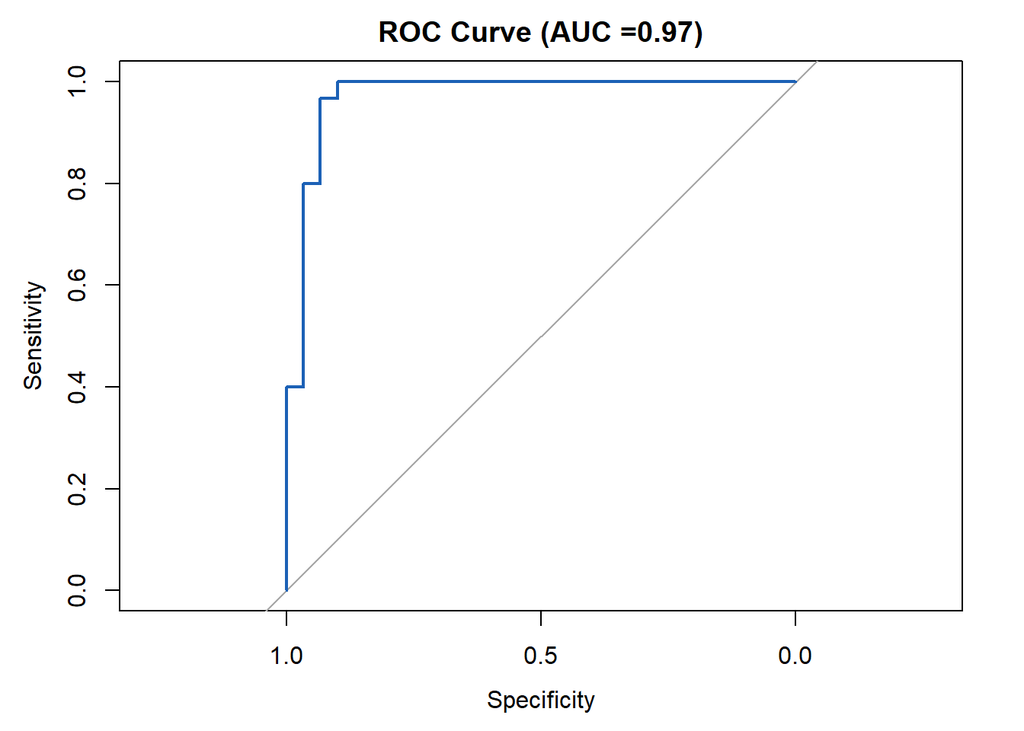

```r
predictions <- predict(art_stat_glm, newdata = testData, type = "response")

roc_curve <- roc(testData$Scenario, predictions)

auc_value <- auc(roc_curve)

# Plot the ROC curve
plot(roc_curve, main=paste0("ROC Curve (AUC =", round(auc_value, digits = 2),")"), col="#1c61b6")
```

## Exploring parameter space

We can use a similar method to explore the parameter space as in the simple model. Here, we are keenly interested in whether the predictive power seen in the last run of our function holds true with varying parameter settings. In this case, we’ll vary the number of artifacts, prestige proportion, prestige learning probability, and prestige strength.

```r
# Function to run simulation and return summarized results
run_simulation <- function(num_artifacts, prestige_proportion, prestige_learning_prob, prestige_strength, generation_choice = "all") {
  df <- generateArtifactData(num_assemblages, num_artifacts, num_generations,
                             initial_mean_length, initial_mean_width,
                             initial_mean_length_sd, initial_mean_width_sd,
                             prestige_proportion, prestige_learning_prob,
                             min_length, max_length, min_width, max_width,
                             human_error_sd, guided_modification_prob,
                             prestige_modification_prob, prestige_learning_modification_prob,
                             prestige_strength)

  # Filter for a specific generation if requested
  if (generation_choice != "all") {
    df <- df %>% filter(Generation == generation_choice)
  }

  # Calculate Mean_Length and SD_Length across all assemblages within each scenario and generation
  overall_summary <- df %>%
    group_by(Scenario, Generation) %>%
    summarise(
      Mean_Length = mean(Length, na.rm = TRUE),
      SD_Length = sd(Length, na.rm = TRUE),
      .groups = 'drop'
    )

  # Calculate VOM, AV, and VOV by assemblage within each scenario and generation
  assemblage_summary <- df %>%
    group_by(Scenario, Generation, Assemblage) %>%
    summarise(
      Assemblage_Mean_Length = mean(Length, na.rm = TRUE),
      Assemblage_SD_Length = sd(Length, na.rm = TRUE),
      .groups = 'drop'
    )

  # Compute VOM, AV, and VOV using assemblage summaries
  variability_measures <- assemblage_summary %>%
    group_by(Scenario, Generation) %>%
    summarise(
      VOM = sd(Assemblage_Mean_Length, na.rm = TRUE),
      AV = mean(Assemblage_SD_Length, na.rm = TRUE),
      VOV = sd(Assemblage_SD_Length, na.rm = TRUE),
      .groups = 'drop'
    )

  # Combine VOM, AV, and VOV with the overall summary
  combined_summary <- left_join(overall_summary, variability_measures, by = c("Scenario", "Generation"))

  return(combined_summary)
}
```

### Calling the run_simulation function

Non-fixed parameters (see code for fixed):

- num_artifacts = 50, 100, 300, 600
- prestige_proportion = 0.1, 0.15, 0.2, 0.3
- prestige_learning_prob_seq = 0.2, 0.3, 0.4, 0.5
- prestige_strength_seq = 0.5, 1, 3, 5

```r
# Fixed parameters
num_assemblages <- 5
num_generations <- 10
initial_mean_length <- 38
initial_mean_width <- 21
initial_mean_length_sd <- 9
initial_mean_width_sd <- 3.75
human_error_sd <- 0.02
guided_modification_prob <- 0.5
prestige_modification_prob <- 0.5
prestige_learning_modification_prob <- 0.0
min_length <- 19.5
max_length <- 69
min_width <- 12.3
max_width <- 32
selected_generation <- "all"  # "all" or a specific generation number

# Define the parameter ranges
num_artifacts_seq <- c(50, 100, 300, 600)
prestige_proportion_seq <- c(0.1, 0.15, 0.2, 0.3)
prestige_learning_prob_seq <- c(0.2, 0.3, 0.4, 0.5)
prestige_strength_seq <- c(0.5, 1, 3, 5)

# Create a grid of parameter combinations
param_grid <- expand.grid(num_artifacts = num_artifacts_seq,
                          prestige_proportion = prestige_proportion_seq,
                          prestige_learning_prob = prestige_learning_prob_seq,
                          prestige_strength = prestige_strength_seq)

results_list <- map(1:nrow(param_grid), function(i) {
  run_simulation(
    num_artifacts = param_grid$num_artifacts[i],
    prestige_proportion = param_grid$prestige_proportion[i],
    prestige_learning_prob = param_grid$prestige_learning_prob[i],
    prestige_strength = param_grid$prestige_strength[i],
    generation_choice = selected_generation
  )
})

# Combine results into a single data frame
results_df <- bind_rows(results_list)
row.names(results_df) <- NULL

# Add parameter values to results_df
results_df <- cbind(results_df, param_grid[rep(seq_len(nrow(param_grid)), each = nrow(results_df) / nrow(param_grid)), ])
```

### Output of the run_simulation function

Head of Output to Explore Parameter Space

Summarized Data per Parameter Combination

| Scenario | Generation | Mean_Length | SD_Length | VOM | AV | VOV | num_artifacts | prestige_proportion | prestige_learning_prob | prestige_strength |
| --- | --- | --- | --- | --- | --- | --- | --- | --- | --- | --- |
| Guided Variation | 1 | 38.62448 | 8.077234 | 0.9488412 | 8.116045 | 0.4544079 | 50 | 0.1 | 0.2 | 0.5 |
| Guided Variation | 2 | 38.76506 | 8.252188 | 0.8017408 | 8.306959 | 0.4555234 | 50 | 0.1 | 0.2 | 0.5 |
| Guided Variation | 3 | 37.65477 | 8.115042 | 1.0035808 | 8.113512 | 0.9649453 | 50 | 0.1 | 0.2 | 0.5 |
| Guided Variation | 4 | 38.71812 | 7.966297 | 1.1746107 | 7.897811 | 1.3432490 | 50 | 0.1 | 0.2 | 0.5 |
| Guided Variation | 5 | 38.30479 | 8.056593 | 1.6155750 | 7.979128 | 0.8803285 | 50 | 0.1 | 0.2 | 0.5 |
| Guided Variation | 6 | 38.93192 | 7.996561 | 1.3002415 | 7.939120 | 1.1333888 | 50 | 0.1 | 0.2 | 0.5 |
| Guided Variation | 7 | 38.66030 | 8.045708 | 1.9834889 | 7.891678 | 0.9604819 | 50 | 0.1 | 0.2 | 0.5 |
| Guided Variation | 8 | 38.35006 | 8.645908 | 1.9578350 | 8.530135 | 0.8592953 | 50 | 0.1 | 0.2 | 0.5 |
| Guided Variation | 9 | 38.26775 | 8.727433 | 2.3715156 | 8.532732 | 0.8071283 | 50 | 0.1 | 0.2 | 0.5 |
| Guided Variation | 10 | 38.06095 | 8.870643 | 1.2317295 | 8.860888 | 0.9842757 | 50 | 0.1 | 0.2 | 0.5 |

### Plot the results

The plots below shows the various non-fixed parameters in relation to the mean and standard deviation of length and our measures of variation they are grouped by prestige strength. However, most of the patterns are present between plots. For example, we can see that mean VOM and VOV measures always have prestige learning above guided variation while AV can go back and forth depending on the model parameters. Length SD and AV values tend to be similar which is expected. This series of plots have much clearer patterns than were observed in the plots associated with the simple model.

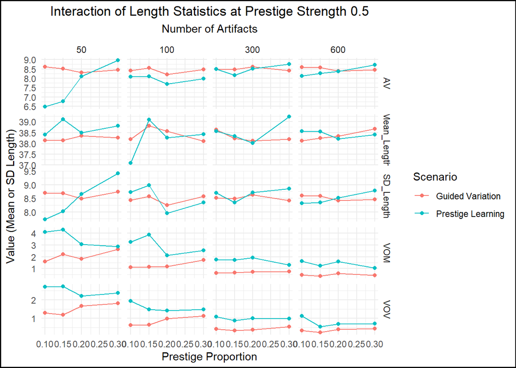

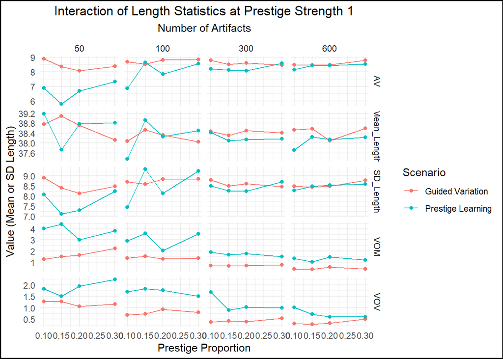

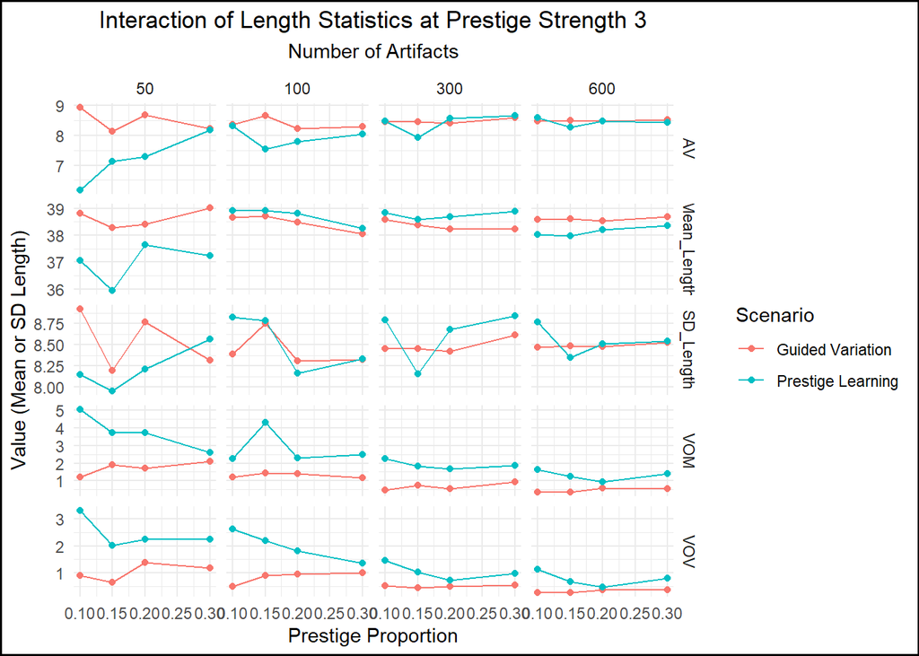

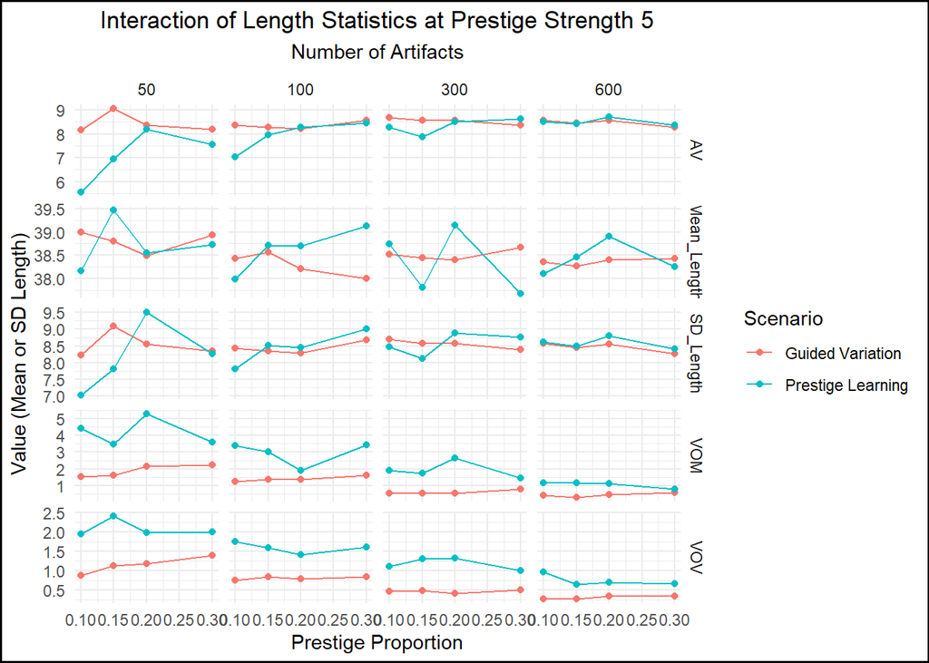

```r
# Pivot the data to long format for ggplot
results_long <- results_df %>%
  pivot_longer(
    cols = c(Mean_Length, SD_Length, VOM, AV, VOV), # Adjust this to match your data frame column names
    names_to = "Statistic", # This will contain the type of statistic (mean or SD)
    values_to = "Value"  # This will contain the values of the statistics
  )

# Unique values of prestige_strength
unique_strengths <- unique(results_long$prestige_strength)
generation_choice<-10

# Create a plot for each unique value of prestige_strength
for(strength in unique_strengths) {
  # Filter the data for the current prestige_strength
  strength_data <- results_long %>%
    filter(prestige_strength == strength, Scenario!= "Prestige", Generation==generation_choice)%>%
    group_by(Scenario, Generation, num_artifacts, prestige_proportion, prestige_strength, Statistic) %>%
  summarise(Value = mean(Value, na.rm = TRUE)) %>%
  ungroup()

  # Create the boxplot
  plot<-ggplot(strength_data, aes(x = prestige_proportion, y = Value, color = Scenario)) +
    geom_line() +
    geom_point()+
    facet_grid(Statistic~ num_artifacts, scales = "free_y") +
    theme_minimal() +
    labs(
      title = paste("Interaction of Length Statistics at Prestige Strength", strength),
      subtitle = "Number of Artifacts",
      x = "Prestige Proportion",
      y = "Value (Mean or SD Length)",
      fill = "Scenario"
    ) +
    theme(plot.title = element_text(hjust = 0.5),
        plot.subtitle = element_text(hjust = 0.5),# Ensure subtitle is centered
        plot.background = element_rect(color ="black", linewidth = 1))

  plot(plot)
}
```

## Predictive signficance of VOM, AV, and VOV

We can again subject that measures of variation to logistic regression as predictor variables to see how robust they are to parameter changes. The results are extremely encouraging and suggest they should fare well. Sensitivity and specificity yield an AUC of 0.83. Assuming the model dynamics accurately reflect what we might expect from prestige learning vs guided variation, we have a good point of departure for interpreting the archaeolgical record.

```r
# Convert 'Scenario' to a factor with levels 'Prestige Learning' and 'Guided Variation'
results_df$Scenario <- factor(results_df$Scenario, levels = c("Prestige Learning", "Guided Variation"))
results_df_glm<-results_df%>%filter(Scenario!="Prestige")

#next we'll split the dataset so we can have training and testing data
set.seed(123)  # for reproducibility
splitIndex <- createDataPartition(results_df_glm$Scenario, p = 0.7, list = FALSE)
trainData <- results_df_glm[splitIndex,]
testData <- results_df_glm[-splitIndex,]

results_df_glm_mod <- glm(Scenario ~ VOM + AV + VOV, family = binomial(), data = trainData)

summary(results_df_glm_mod)
```

```
##
## Call:
## glm(formula = Scenario ~ VOM + AV + VOV, family = binomial(),
##     data = trainData)
##
## Coefficients:
##             Estimate Std. Error z value             Pr(>|z|)
## (Intercept) -4.36483    0.71043  -6.144       0.000000000805 ***
## VOM         -0.75374    0.06108 -12.339 < 0.0000000000000002 ***
## AV           0.77800    0.08285   9.391 < 0.0000000000000002 ***
## VOV         -0.99785    0.09042 -11.036 < 0.0000000000000002 ***
## ---
## Signif. codes:  0 '***' 0.001 '**' 0.01 '*' 0.05 '.' 0.1 ' ' 1
##
## (Dispersion parameter for binomial family taken to be 1)
##
##     Null deviance: 4968.5  on 3583  degrees of freedom
## Residual deviance: 3557.5  on 3580  degrees of freedom
## AIC: 3565.5
##
## Number of Fisher Scoring iterations: 5
```

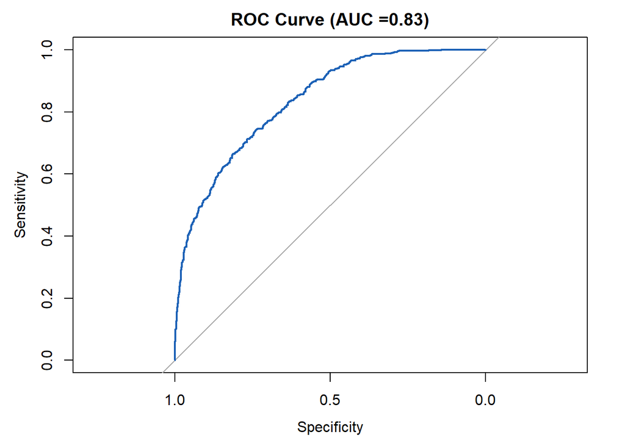

```r
predictions <- predict(results_df_glm_mod, newdata = testData, type = "response")

roc_curve <- roc(testData$Scenario, predictions)
auc_value <- auc(roc_curve)

# Plot the ROC curve
plot(roc_curve, main=paste0("ROC Curve (AUC =", round(auc_value, digits = 2),")"), col="#1c61b6")
```

## Conculsions about the more realistic model

Based on these preliminary data, the model appears to be very useful. The underlying dynamics of the function are specific to each learning scenario and should provide a simulation dataset adequate to begin untangling the dynamics in prestige-biased social learning.

**this discussion needs some work**

# Classifying emprical datasets

First we can read in the empirical data I’ve gathered thus far. I probably need to clean it up to and remove extraneous variables. I started it by copying the FWARG database for the Ruby Pipeline and have kept that format when adding data from different sources. However, as we all know, there is a lot of variability in how groups collect their data and even which variables are collected. The variables I focus on are Length, Width, etc. along with shoulder angle measures like DSA and PSA. Below, I provide both the head and tail of the data frame. Following that, I filter for projecte points that are Elko Series and then extract each variable of interest and add it to a list as its own data frame. I have NA values for some projectile points variables but not others, so each data set has a different number of observations. I only keep observations I believe to be complete.

```r
#read in data

data<-read.csv(file = "CombinedData.csv")

head(data,10)
```

```
##    Source           Catalog      Site Locus    ProvString           Component
## 1    Ruby  26EK-ISO-10-3563  26EK-ISO     -             -
## 2    Ruby  26EK-ISO-10-3564  26EK-ISO     -             -
## 3    Ruby  26EK-ISO-10-3565  26EK-ISO     -             -
## 4    Ruby  26EK2024-10-3566  26EK2024     - PL Artifact 1       Non-component
## 5    Ruby 26EK11799-10-3568 26EK11799    C1 PL Artifact 1 Middle Archaic (C1)
## 6    Ruby 26EK11801-10-3569 26EK11801     - PL Artifact 1
## 7    Ruby 26EK11803-10-3574 26EK11803     A PL Artifact 1
## 8    Ruby 26EK11804-10-3580 26EK11804    NL PL Artifact 1
## 9    Ruby 26EK11851-10-3585 26EK11851     A PL Artifact 1       Non-component
## 10   Ruby 26EK11851-10-3586 26EK11851     A PL Artifact 2       Non-component
##    Ct  Wt                  MtlString         CndString    ML    AL    MW MTH
## 1   1 4.3 Cryptocrystalline silicate Proximal fragment  32.6  31.7  19.8 6.6
## 2   1 4.1 Cryptocrystalline silicate Proximal fragment -41.9 -41.5 -20.9 5.7
## 3   1 0.9 Cryptocrystalline silicate Proximal fragment -20.6 -20.3 -17.3 3.5
```

[output cut: 18 more lines]

```r
tail(data,10)
```

```
##         Source Catalog             Site Locus ProvString Component Ct Wt
## 2931 Smith_LSC 31-1026 Last Supper Cave                             1 NA
## 2932 Smith_LSC 31-1887 Last Supper Cave                             1 NA
## 2933 Smith_LSC  31-202 Last Supper Cave                             1 NA
## 2934 Smith_LSC 31-3382 Last Supper Cave                             1 NA
## 2935 Smith_LSC 31-4174 Last Supper Cave                             1 NA
## 2936 Smith_LSC 31-4196 Last Supper Cave                             1 NA
## 2937 Smith_LSC 31-4198 Last Supper Cave                             1 NA
## 2938 Smith_LSC 31-4312 Last Supper Cave                             1 NA
## 2939 Smith_LSC  31-496 Last Supper Cave                             1 NA
## 2940 Smith_LSC  31-598 Last Supper Cave                             1 NA
##      MtlString CndString    ML   AL  MW  MTH   BW  NW PSA DSA MXWP STL Comments
## 2931       ccs           -13.0   NA  12  3.0  7.0 6.0 120 140   NA  NA
## 2932       ccs           -30.0   NA  20  4.0  9.5 8.0 110 115   NA  NA
## 2933       ccs           -13.0   NA  14  3.5  8.0 6.0 110 145   NA  NA
```

[output cut: 18 more lines]

```r
#create a vector of column names that I want to replace any negative or empty values with na
cols_to_check <- c("ML", "AL", "MW", "MTH", "BW", "NW", "DSA", "PSA")  # Add more columns as necessary
#attribute value must be greater than 0, otherwise it's na
data[cols_to_check] <- lapply(data[cols_to_check], function(x) ifelse(x < 0, NA, x))
```

```r
#Filter for point type Elko
data <- data %>%
  filter(PointType == "Elko" | PointType == "Elko?")

         # & (CndString == "Whole" | CndString == "Nearly complete"))

#remove isolates
data <- data %>%
  filter(!str_detect(Site, "-ISO"))
```

```r
#function to subset data into each attribute in cols_to_check and site number

create_separate_dataframes <- function(data, cols_to_check) {
  # List to store dataframes
  data_list <- list()

  # Loop through each variable
  for (col in cols_to_check) {
    # Subset the data
    temp_data <- data[, c("Site", col)]

    # Remove NA values
    temp_data <- temp_data[!is.na(temp_data[col]),]

    # Filter out sites with less than 20 observations
    temp_data <- temp_data %>%
      group_by(Site) %>%
      filter(n() >= 20) %>%
      ungroup()

    # Store in the list with a name like "dataVarName"
    data_list[[paste0("data", col)]] <- temp_data
  }

  return(data_list)
}
```

## Structure of the data set after processing

Here you can see how each dataframe of the list is structured. Each site has a number of complete maximum length and axial length measurements that I’ve retained for analysis.

```r
data_list <- create_separate_dataframes(data, cols_to_check)
head(data_list[[1]])
```

```
## # A tibble: 6 × 2
##   Site     ML
##   <chr> <dbl>
## 1 Ch-13  28
## 2 Ch-13  27.7
## 3 Ch-13  30.7
## 4 Ch-15  26.8
## 5 Ch-15  25.4
## 6 Ch-15  31
```

```r
head(data_list[[2]])
```

```
## # A tibble: 6 × 2
##   Site     AL
##   <chr> <dbl>
## 1 Ch-13  27.5
## 2 Ch-13  27.7
## 3 Ch-13  30
## 4 Ch-15  25.9
## 5 Ch-15  23.6
## 6 Ch-15  30
```

## Plotting the emprical data

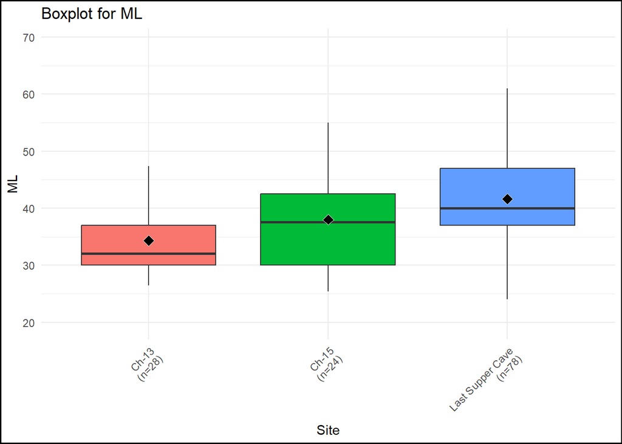

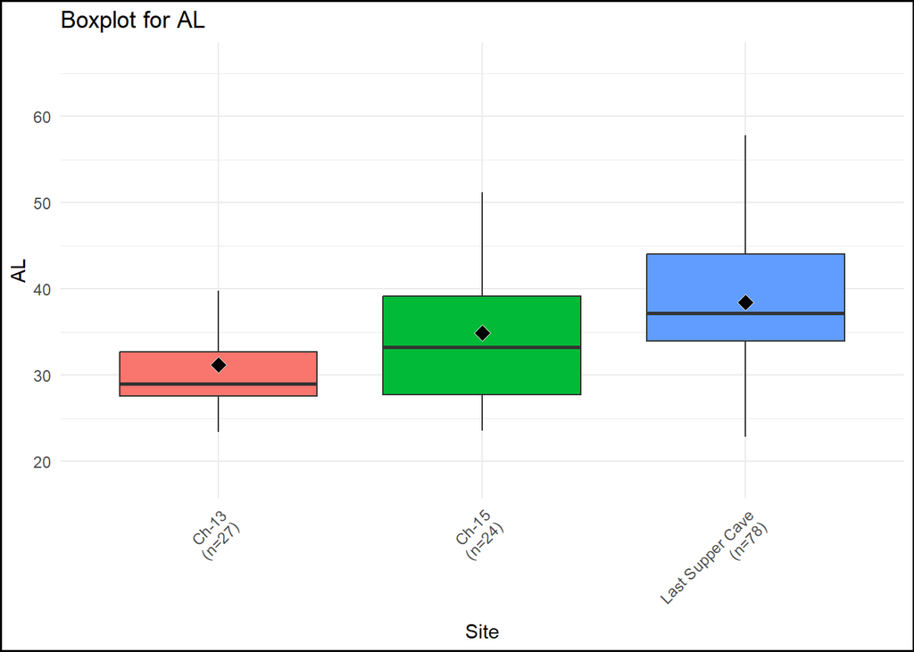

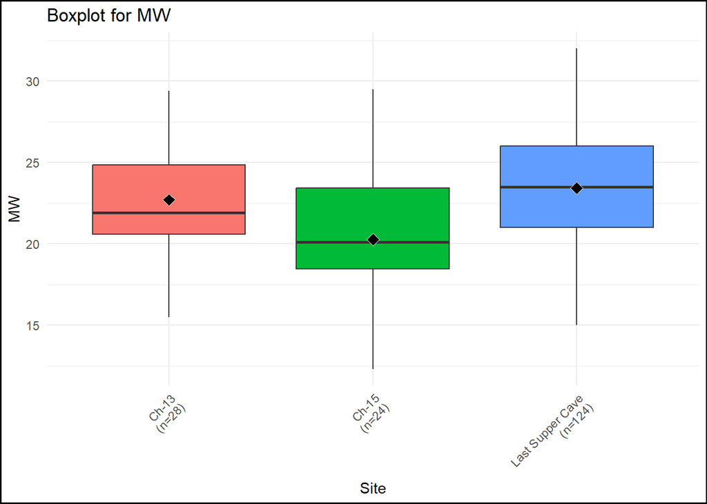

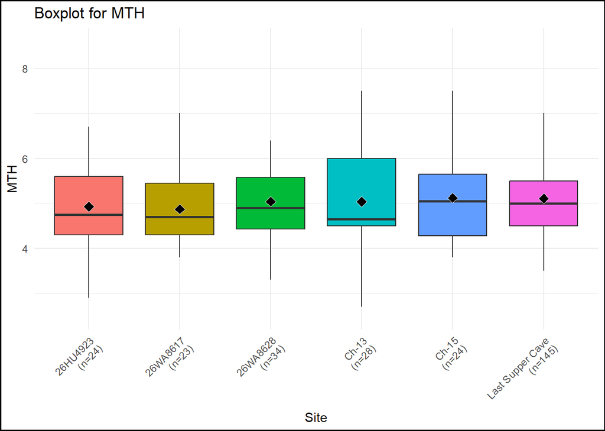

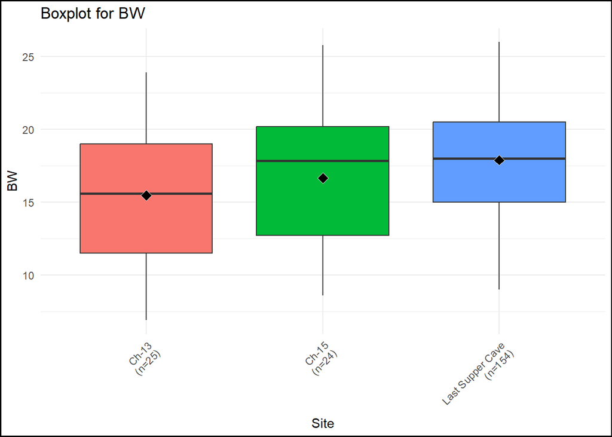

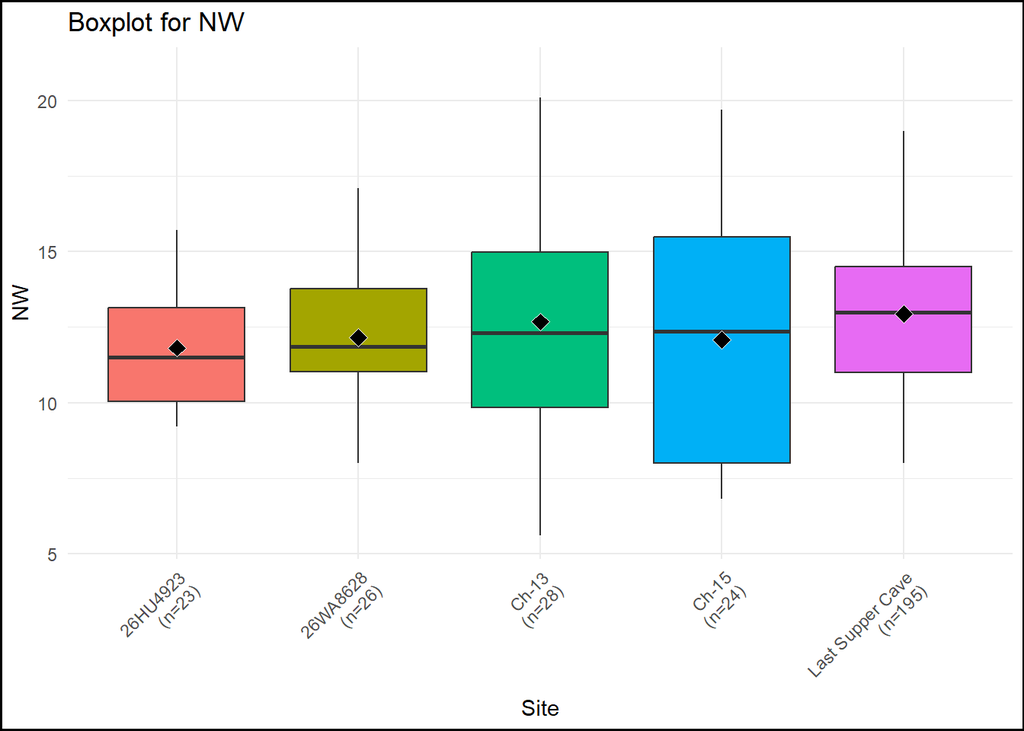

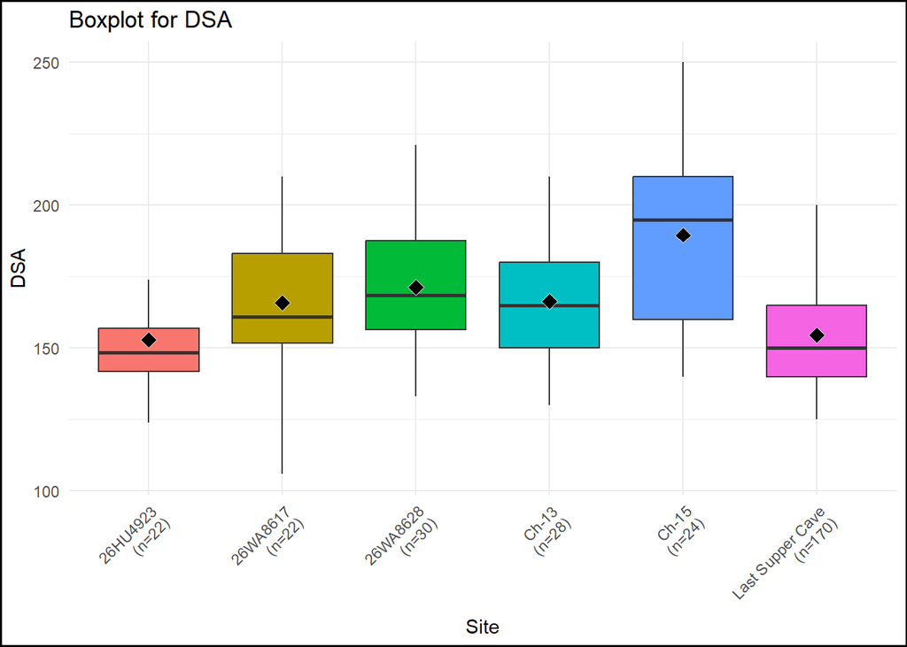

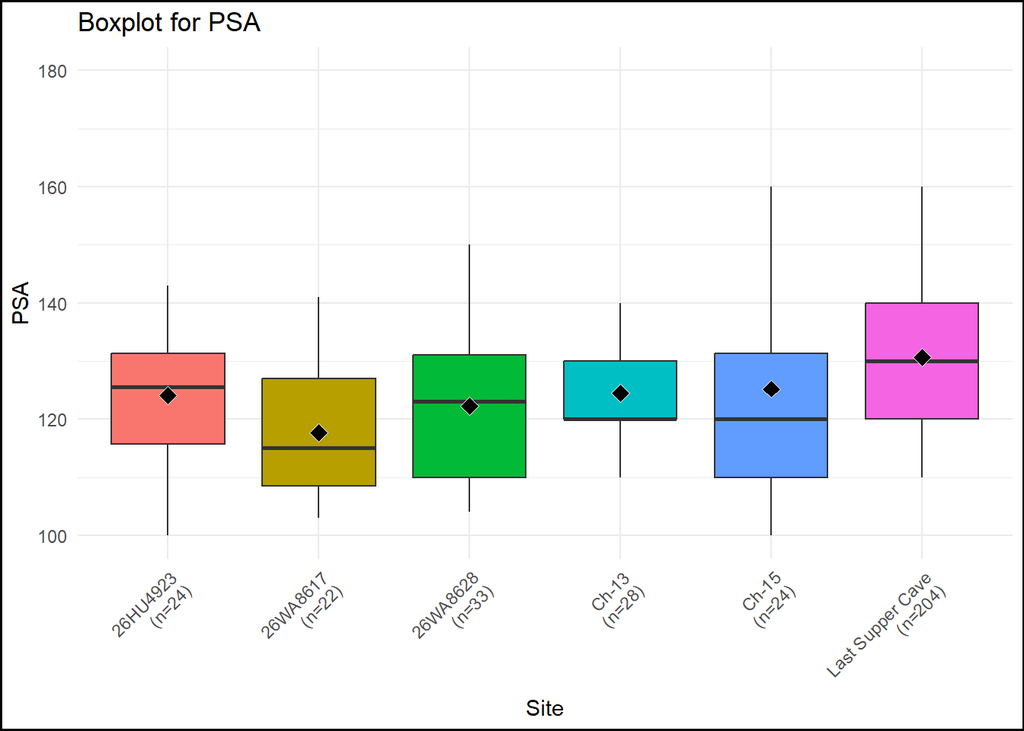

```r
# Loop through each dataframe in the list to create a boxplot
for (df_name in names(data_list)) {
  df <- data_list[[df_name]]

  # Extract variable name (removing "data" prefix)
  var_name <- sub("^data", "", df_name)

  # Calculate mean and count for each site
  stats <- df %>%
    group_by(Site) %>%
    summarise(Mean = mean(!!sym(var_name)), Count = n())

# Create a new column in the stats dataframe to hold the new label
stats$Site_Label <- paste(stats$Site, "\n(n=", stats$Count, ")", sep = "")

# Create the boxplot
p <- ggplot(df, aes(x = Site, y = !!sym(var_name), fill = Site)) +
    geom_boxplot(outlier.shape = NA) +  # avoid displaying outliers twice
    geom_point(data = stats, aes(y = Mean, group = Site),
               shape = 23, fill = "black", color = "white", size = 3,
               position = position_dodge(width = 0.75)) +
    labs(title = paste("Boxplot for", var_name),
         y = var_name) +
    scale_x_discrete(labels = stats$Site_Label) +
    theme_minimal() +
    theme(legend.position = "none", axis.text.x = element_text(angle = 45, hjust = 1),
          plot.background = element_rect(color ="black", linewidth = 1))

# Display the plot
print(p)
}
```

## Calculating VOM, AV, and VOV for the empircal data I created a function that goes through the dataframe and calculates the measures by grouping assemblages together, calculating mean and SD, and then using those measures to calculate VOM, AV, and VOV. The lapply function is then used to apply the function on all of the different dataframes within our list.

```r
# Function to calculate AV, VOM, and VOV for a dataframe
calculate_metrics <- function(df, measurement) {
  # Extract the actual measurement column name (e.g., "ML" from "dataML")
  measurement_col <- sub("data", "", measurement)

  stats_by_site <- df %>%
    group_by(Site) %>%
    summarise(
      Mean = mean(.data[[measurement_col]], na.rm = TRUE),
      SD = sd(.data[[measurement_col]], na.rm = TRUE)
    ) %>%
    ungroup() # Ungroup for further calculations

  # Calculate AV, VOM, and VOV
  av <- mean(stats_by_site$SD, na.rm = TRUE)
  vom <- sd(stats_by_site$Mean, na.rm = TRUE)
  vov <- sd(stats_by_site$SD, na.rm = TRUE)

  return(data.frame(AV = av, VOM = vom, VOV = vov))
}
```

```r
 #Make sure the names of the dataframes in your list are like "dataML", "dataAL", etc.
results <- lapply(names(data_list), function(measurement) {
  df <- data_list[[measurement]]
  metrics <- calculate_metrics(df, measurement)
  cbind(Dimension = sub("data", "", measurement), metrics)
})

combined_results <- do.call(rbind, results)

combined_results
```

```
##   Dimension         AV         VOM       VOV
## 1        ML  8.4130096  3.65603475 1.9850276
## 2        AL  7.9031837  3.63522250 1.9361241
## 3        MW  3.8718805  1.64574533 0.5061923
## 4       MTH  0.9846695  0.09937067 0.1540173
## 5        BW  4.3828983  1.20852249 0.6842878
## 6        NW  2.9923537  0.46253781 0.9869781
## 7       DSA 22.3344231 13.26613391 5.2814851
## 8       PSA 12.4265909  4.24161778 3.0869645
```

## Predicting Scenario from the GLM

Next we can use the GLM developed for the parameter space exploration to predict the most likely scenario in this instance. I do this for all of the dimensions on my list; however, the model is only applicable to ML. To apply it to other measures, I’ll need to rerun it and input empirical data specific to those datasets.

```r
model_variables <- names(coef(results_df_glm_mod))

combined_results$predicted_response <- predict(results_df_glm_mod, newdata = combined_results, type = "response")

# "Prestige Bias" is the first level and "Guided Variation" is the second level
combined_results$Scenario <- ifelse(combined_results$predicted_response > 0.5,
                                           "Guided Variation", "Prestige Learning")

combined_results
```

```
##   Dimension         AV         VOM       VOV predicted_response
## 1        ML  8.4130096  3.65603475 1.9850276         0.07202661
## 2        AL  7.9031837  3.63522250 1.9361241         0.05274362
## 3        MW  3.8718805  1.64574533 0.5061923         0.04318676
## 4       MTH  0.9846695  0.09937067 0.1540173         0.02130370
## 5        BW  4.3828983  1.20852249 0.6842878         0.07251652
## 6        NW  2.9923537  0.46253781 0.9869781         0.03323783
## 7       DSA 22.3344231 13.26613391 5.2814851         0.09466101
## 8       PSA 12.4265909  4.24161778 3.0869645         0.27401568
##            Scenario
## 1 Prestige Learning
## 2 Prestige Learning
## 3 Prestige Learning
## 4 Prestige Learning
## 5 Prestige Learning
## 6 Prestige Learning
## 7 Prestige Learning
## 8 Prestige Learning
```

## Plotting our emprical variation values against the simulated values

We can plot our empirical values against the values from our single simulation (the getArtifactData function) and against our parameter exploration values (the run_simulation function) to see where they are in comparison. As you can see below, VOM and VOV for our empirical maximum length data falls slightly outside our single simulation data but well within the values associated with our parameter exploration data. Moving forward, we might ask what the parameter combinations are that surround our emprical point to assess what kind of social conditions might have resulted in the emprical pattern.

```r
combined_results$Source <- "Empirical"
artifact_stats$Source <- "Artifact Stats"
results_df$Source<-"Param Explore"

artifact_stats_selected <- artifact_stats %>%
  select(Scenario, VOM, AV, VOV, Source)

results_df_selected <- results_df %>%
  select(Scenario, VOM, AV, VOV, Source)

combined_results_selected <- combined_results %>%
  filter(Dimension=="ML")%>%
  select(Scenario, VOM, AV, VOV, Source)

combined_data <- rbind(combined_results_selected, artifact_stats_selected, results_df_selected)
combined_data<- combined_data %>% filter(!is.na(Scenario))
```

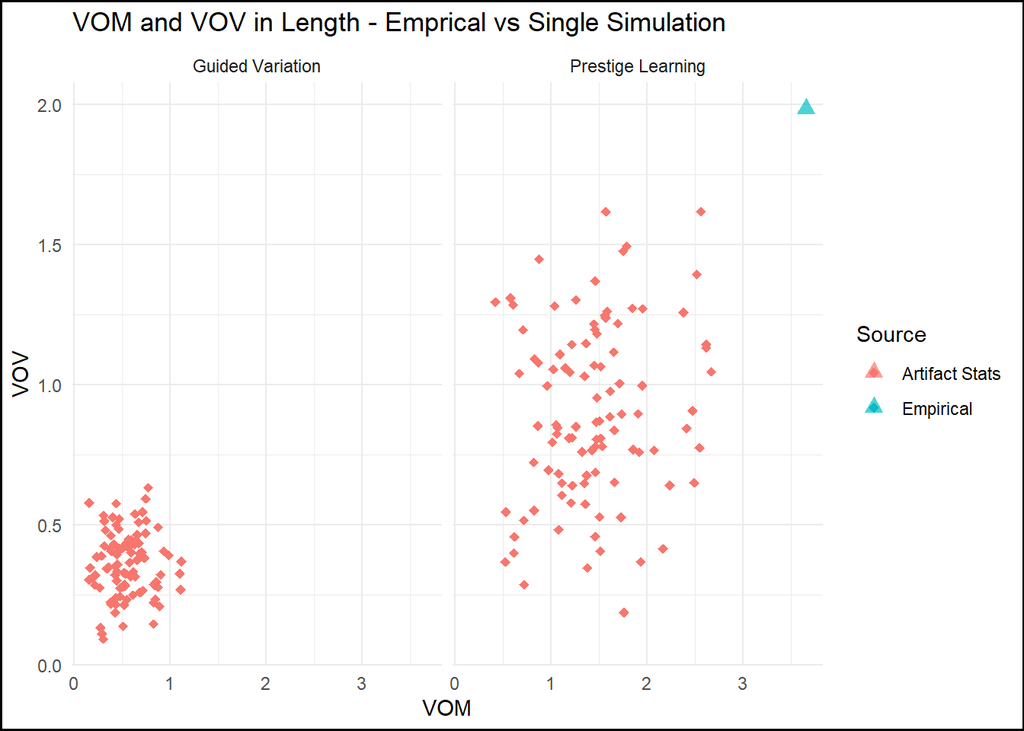

```r
# Base plot with artifact stats data
plot_vom_vov1 <- ggplot() +
  geom_point(data = subset(combined_data, Source == "Artifact Stats"),
             aes(x = VOM, y = VOV, color=Source),
             shape=18, size=2) +
  geom_point(data = subset(combined_data, Source == "Empirical"),
             aes(x = VOM, y = VOV, color = Source),
             shape = 17, size = 3, alpha = 0.7) +
  facet_wrap(~Scenario) +
  theme_minimal() +
  labs(title = "VOM and VOV in Length - Emprical vs Single Simulation", x = "VOM", y = "VOV")+
  theme(plot.background = element_rect(color ="black", linewidth = 1))

plot_vom_vov1
```

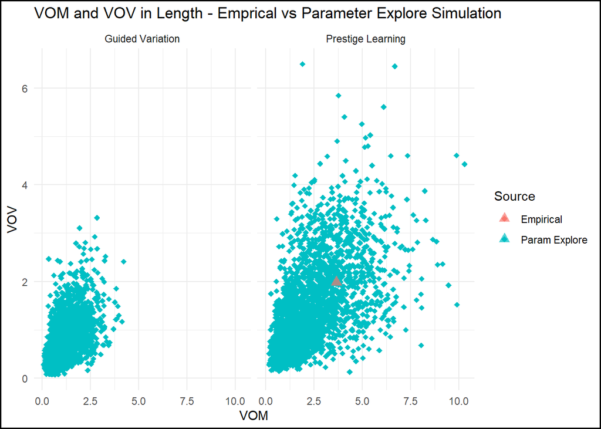

```r
# Base plot with parameter exploration data
plot_vom_vov2 <- ggplot() +
  geom_point(data = subset(combined_data, Source == "Param Explore"),
             aes(x = VOM, y = VOV, color=Source),
             shape=18, size=2) +
  geom_point(data = subset(combined_data, Source == "Empirical"),
             aes(x = VOM, y = VOV, color = Source),
             shape = 17, size = 3, alpha = 0.7) +
  facet_wrap(~Scenario) +
  theme_minimal() +
  labs(title = "VOM and VOV in Length - Emprical vs Parameter Explore Simulation", x = "VOM", y = "VOV")+
  theme(plot.background = element_rect(color ="black", linewidth = 1))

plot_vom_vov2
```